# 复杂网络直径计算探索

2016年8月

## 近几年相关论文

- (1999)Fast Estimation of Diameter and Shortest Paths without matrix multiplication; D. Aingworth, C. Checkuri, R. Motwani;\(O(m\sqrt{n \log n} + n^2\log n)\)
- (2013)Fast Approximation Algorithms for the Diameter and Radius of Sparse Graphs;Liam Roditty, Virginia Vassilevska Williams;\(O(mn^{1/2})\)
- (2014)Better Approximation Algorithms for the Graph Diameter;Shiri Chechik; Daniel H. Larkin, Liam Roditty, Grant Schoenebeck, Robert E. Tarjan, Virginia Vassilevska Williams;\(O(m^{3/2});O(mn^{2/3})\)
- (2011)Determiing the Diameter of Small world Networks;Frank W. Takes,Walter A. Kosters;O(mn),小世界网络效果非常好，但是没有理论证明。

前三篇论文思想一脉相承，均是估算直径范围，有严格数学理论证明，复杂度较高；最后一篇，无理论证明，复杂度较高，但实验显示，在小世界网络有较好效果，且可以计算精确直径。

## 小世界网络直径计算

**算法思路**

根据当前点的离心率，推断所有其他点的离心率。由于直径等于最大离心率，所以可以不断缩小直径的上界和下界，同时排除掉那些对上界和下界没有贡献的点。最终得到精确的直径。

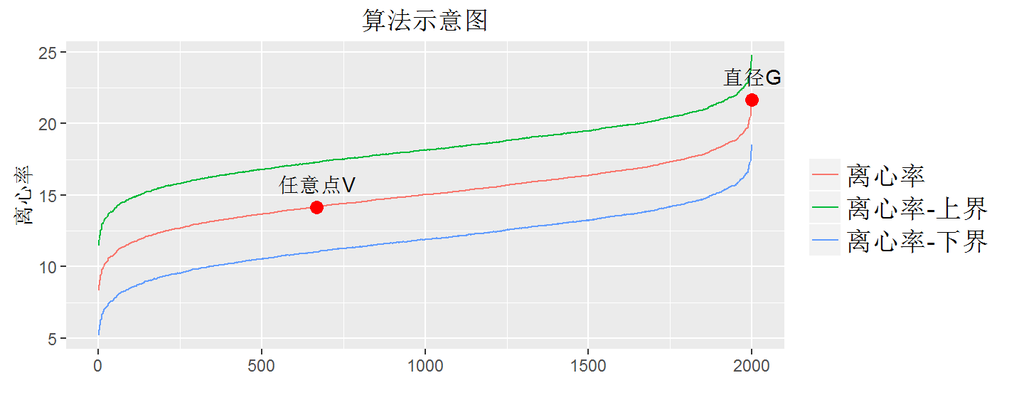

## 相关定义与推论-Part 1

定义1: \(dist(v,w)\)是点\(v\)到\(w\)的最短路径长度

定义2：离心率\(\epsilon(v)\)是节点\(v\)到其他点的最大最短路径

\[ \epsilon(v) = \max_{w \in V} dist(v,w) \]

推论1: 直径\(\Delta G\)与离心率的关系

\[ \Delta G = \max_{v \in V} \epsilon(v) \\ \epsilon(v) \le \Delta (G) \le 2\epsilon(v) \]

## 相关定义与推论-Part 2

推论2：离心率界线,已知点\(v\)的离心率\(\epsilon(v)\)，对任意点\(w \in V\)(包括\(v\))有

\[ \max(\epsilon(v) - dist(v,w), dist(v,w)) \le \epsilon(w) \le \epsilon(v) + dist(v,w) \]

定义3：\(\epsilon_L(v)\)为当前点离心率下界，\(\epsilon_L(v)\)为离心率上界。

推论3: 直径界限

\[ \max_{v \in V}\epsilon_L(v)\le \Delta(G) \le \min(\max_{v \in V}\epsilon_U(v), 2*\min_{v \in V}\epsilon_U(v)) \]

## 实验及结果-多数据计算

| 数据 | 有向 | 有权 | 节点数 | 边数 | 直径 | SSSP轮数 | 描述 |
| --- | --- | --- | --- | --- | --- | --- | --- |
| AstroPhys | 无 | 无 | 17,903 | 394,003 | 14 | 27.80 | 天文物理论文协作网络，一起发过论文的科学家作为边 |
| Enron | 无 | 无 | 33,696 | 180,811 | 13 | 18.73 | Enron公司邮件网络，有过邮件交互算作一条边 |
| Skitter | 无 | 无 | 1,694,616 | 11,094,209 | 31 | 7.65 | 互联网拓扑结构，2005年 |
| Web | 有 | 无 | 855,802 | 5,066,842 | 24 | 6.60 | Google抓取的互联网页面网络，2002年 |
| CF 5次+ | 有 | 有 | 892,151 | 9,273,672 | 9520 | 3.75 | CF对局，5次及以上作为边 |

以上试验使用R单机实现，每一组数据均试验20轮，取平均需要的SSSP轮数。SSSP轮数相比于节点数，基本上可以忽略不计。

## 实验及结果-边界趋势

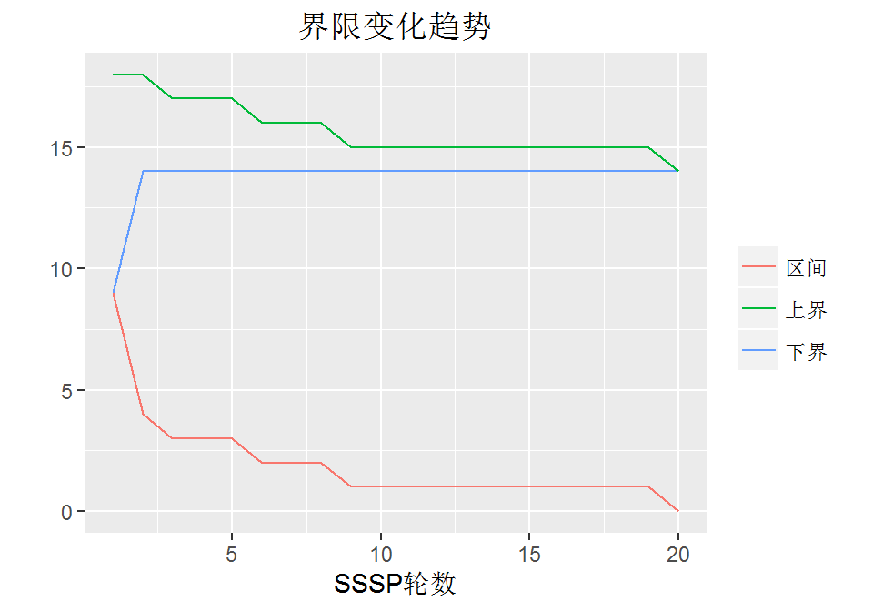

- 选取天体物理论文网络
- 上下界收敛非常快

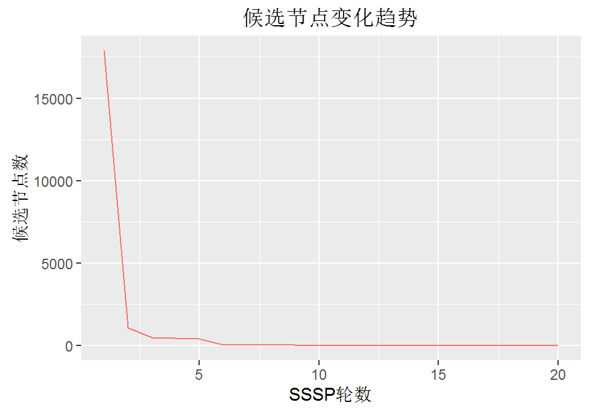

- 备选节点在前几轮SSSP，急剧下降

## 参考资料

- [图直径与离心率(eccentricity)相关推论](http://bourneli.github.io/graph/2016/08/03/diamter-and-eccsentricity.html)
- [精确计算小世界网络直径](http://citeseerx.ist.psu.edu/viewdoc/download?doi=10.1.1.432.9105&rep=rep1&type=pdf)